# Thema 9 · *t*-toets

Deel 5 — Toetsen · *de σ die we niet kennen*

# Van *z* naar *t*: *σ* kennen we nooit

In thema 8 deden we alsof we $\sigma_x$ kennen. Dat is een prettige fictie voor het uitleggen, maar in de echte wereld komt zo’n populatie-standaardafwijking nooit kant-en-klaar binnenwaaien. We **schatten** $\sigma_x$ met de standaardafwijking van onze steekproef: $s_x$. En dat extra schatten kost ons iets — vandaar een nieuwe verdeling: de **t-verdeling**.

**OpmerkingDe egels — nu zonder cadeau van God**

Zelfde context als thema 8: pienterheid, $H_0: \mu_x = 100$, $H_1: \mu_x > 100$, $\alpha = .05$, steekproef van $n = 25$ egels met $\bar{x} = 106$. Maar nu: $\sigma_x$ kennen we *niet* (alleen God kende ’m). We hebben $s_x = 15$ uit de steekproef — onze beste gok.

# Wat verandert er?

Drie dingen, en eigenlijk maar drie:

1. De **standaardfout** wordt geschat: $SE_{\bar{x}} =s_x / \sqrt{n}$ in plaats van $\sigma_x / \sqrt{n}$.
2. De **toetsingsgrootheid** heet $t$ in plaats van $z$ — zelfde formule, andere naam: $t = \dfrac{\bar{x} - \mu_0}{SE_{\bar{x}}}$.
3. We zoeken de kans op in de **t-verdeling met $n-1$ vrijheidsgraden** ($df$), niet in de z-tabel.

Voor onze egels: $SE_{\bar{x}} =15/\sqrt{25} = 3$ (toevallig gelijk aan thema 8 — handig voor het vergelijken). $df = n - 1 = 24$.

# De *t*-verdeling: *z*, maar met extra onzekerheid in de staarten

De t-verdeling lijkt op de standaardnormale, maar heeft **dikkere staarten** — meer kans op extreme uitkomsten. En daarom moet je bewijs ook iets sterker zijn: de kritieke grens ligt iets verder van het midden dan bij $z$ (je zag het in de figuur: $\bar{x}_c = 105{,}13$ in plaats van $104{,}94$). Die dikkere staarten krijg je precies doordat je $\sigma$ door $s$ vervangt: $s$ is zelf ook een schatting met ruis, dus de hele toetsstatistiek wordt iets onzekerder. Hoe groter $n$ (dus $df$), hoe beter $s$ de echte $\sigma$ benadert, en hoe meer de t-verdeling op de z-verdeling lijkt. Bij $df = \infty$ valt t samen met z.

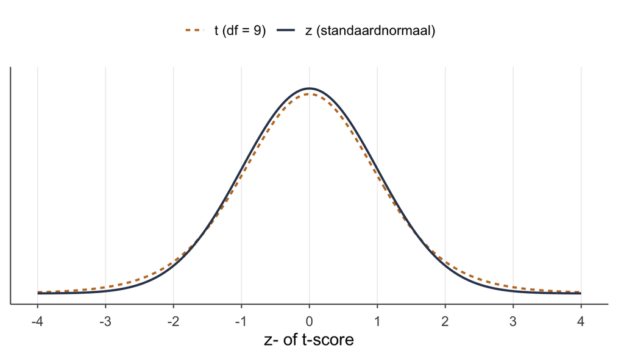

Figuur 1: De standaardnormale verdeling (z, donkergrijs, doorgetrokken) en de t-verdeling bij df = 9 (oranje, gestippeld). De t-verdeling heeft dikkere staarten en een iets lagere top — meer onzekerheid in de extremen. Bij df = 24 is het verschil al klein; bij df → ∞ vallen ze samen.

**TipVrijheidsgraden — een korte intuïtie**

Met $n$ scores en een vastgelegd gemiddelde, mogen $n-1$ scores nog vrij wisselen — de laatste ligt vast (anders verandert het gemiddelde). Vandaar $df = n - 1$. En omdat we $s_x$ rond datzelfde steekproefgemiddelde berekenen, verliezen we precies die ene vrijheid — daarom duikt $df$ juist bij de t-toets (met geschatte $s$) op. Hoe meer vrijheidsgraden, hoe stabieler $s_x$ als schatting van $\sigma_x$, hoe smaller de staarten.

# De snelle weg (3 regels, overzicht)

Voor de egels ($\bar{x} = 106$, $s_x = 15$, $n = 25$, $\mu_0 = 100$, eenzijdig, $\alpha = .05$):

1. **Standaardiseer:** $t = \dfrac{\bar{x} - \mu_0}{SE_{\bar{x}}} = \dfrac{106 - 100}{3} = 2{,}00$ met $df = 24$.
2. **Zoek de kans:** $p = .028$ (rechterstaart, t-tabel df = 24). $p < .05$.
3. **Beslis:** verwerp de nulhypothese.

**Conclusie:** ook zonder $\sigma_x$ als cadeau scoren egels significant boven de norm van 100. Klaar.

# De lange weg — het toets-stappenplan

**Stap 1 · Onderzoeksvraag.** Zijn egels pienterder dan de norm van 100?

**Stap 2 · Hypothesen.** $H_0: \mu_x = 100$. $H_1: \mu_x > 100$ (rechtszijdig).

**Stap 3 · Toetskeuze.** Eén gemiddelde, $\sigma_x$ **onbekend** → **één-steekproefs t-toets** (in plaats van z).

**Stap 4 · Laat $H_0$ waar zijn en teken de steekproevenverdeling.** Onder $H_0$ ligt het centrum op $\mu_0 = 100$ met geschatte standaardfout $SE_{\bar{x}} =15/\sqrt{25} = 3$. De rechterstaart van 5% (= $\alpha$) is het verwerpingsgebied — maar nu met t (df = 24), niet met z:

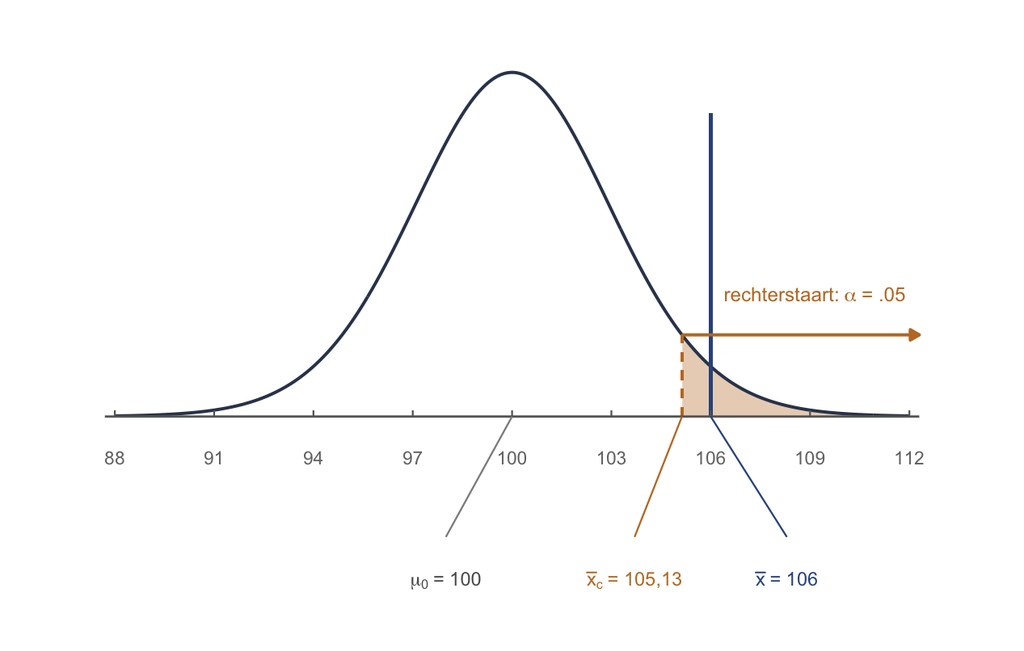

Figuur 2: De steekproevenverdeling onder H0 (mu0 = 100, geschatte standaardfout 3, t-verdeling met df = 24). De oranje staart is het verwerpingsgebied (α = .05); de kritieke waarde ligt op x̄c = 105,13 (iets verder dan T8’s 104,94, omdat de t-verdeling extra onzekerheid in de staart inbouwt). De gevonden steekproef x̄ = 106 (blauwe lijn) valt nog steeds in het verwerpingsgebied → verwerpen.

**Stap 5 · Toetsingsgrootheid.** $t = \dfrac{\bar{x} - \mu_0}{SE_{\bar{x}}} = \dfrac{106 - 100}{3} = 2{,}00$.

**Stap 6 · p-waarde of kritieke waarde.**

- *p-waarde:* in de t-tabel bij $df = 24$ hoort bij $t = 2{,}00$ een eenzijdige $p \approx .028$. (Vergelijk T8: voor $z = 2{,}00$ was $p = .023$. T levert iets hogere $p$ — de dikkere staart.)
- *Kritieke waarde:* bij $\alpha = .05$ eenzijdig en $df = 24$ is $t^* = 1{,}711$. Dus $\bar{x}_c = 100 + 1{,}711 \cdot 3 = 105{,}13$. De gevonden $\bar{x} = 106 > 105{,}13$ → verwerpen.

**Stap 7 · Statistische beslissing.** Verwerp de nulhypothese ($t = 2{,}00$, $df = 24$, $p = .028$, eenzijdig, $\alpha = .05$).

**Stap 8 · Inhoudelijke conclusie.** **Bij egels ligt de gemiddelde pienterheid significant boven de norm van 100** — ook nu we $\sigma_x$ niet kenden en met $s_x$ moesten werken.

**Belangrijkt-tabel afwijkend van z-tabel — en de procenten-rij**

De t-tabel is anders opgebouwd dan de z-tabel: je zoekt in de **kolom** een tail-percentage (5%, 2,5%, …) en in de **rij** je $df$ — daar staat de kritieke $t^*$. (Bij de z-tabel zoek je in het binnenwerk een kans-bij-een-z; de t-tabel is bewust korter.) In schema:

- **z-tabel:** $z \;\to\;$ kans
- **t-tabel:** $df$ + staartpercentage $\;\to\;$ kritieke $t^*$ Voor $df = 24$ en eenzijdig 5%: $t^* = 1{,}711$. Voor $df \to \infty$ zie je 1,645 staan — exact de z-waarde. Dat is dezelfde “procenten-rij” als het college gebruikt; alleen vraag jij ’m rechtstreeks (“welke $t$ bij 5% in één staart bij df = 24?”) in plaats van via de p-waarde.

# Het *t*-betrouwbaarheidsinterval

Net als in thema 7 kun je rond $\bar{x}$ een interval bouwen, maar nu met $t^*$ in plaats van $z^*$ en met $SE_{\bar{x}}$ in plaats van $\sigma_{\bar{x}}$:

$$\bar{x} \pm t^* \cdot SE_{\bar{x}}$$

Voor 95% tweezijdig bij $df = 24$: $t^* = 2{,}064$ (uit de t-tabel). Dus $106 \pm 2{,}064 \cdot 3 = 106 \pm 6{,}19 = [99{,}81\,;\,112{,}19]$. Iets breder dan T8’s $z$-CI $[100{,}12\,;\,111{,}88]$ — de prijs van het schatten. Let op: hier ligt 100 wél nét binnen het interval — dus bij een tweezijdige toets ($\alpha = .05$, $H_1: \mu \neq 100$) zou je deze nét niet verwerpen. Eenzijdig wel.

# Twee andere *t*-toetsen — kort

Tot nu toe één steekproef tegen een norm. In de echte wereld vergelijk je vaker twee dingen. *Oriëntatie, geen toetsstof voor nu: je hoeft de formules hieronder nog niet te kunnen toepassen — herken vooral het patroon (een verschil delen door zijn standaardfout).*

**TipDe onafhankelijke (independent samples) t-toets — twee groepen**

**Wanneer?** Je vergelijkt twee verschillende groepen op één variabele (bijv. egels vs marmotten op pienterheid). $H_0: \mu_1 = \mu_2$.

**Formule (pooled):** $t = \dfrac{\bar{x}_1 - \bar{x}_2}{SE_{\text{verschil}}}$ met $SE_{\text{verschil}} = s_p\sqrt{\tfrac{1}{n_1} + \tfrac{1}{n_2}}$ en $s_p$ de “samengetrokken” SD; $df = n_1 + n_2 - 2$.

De rest van het stappenplan blijft hetzelfde — verwacht onder $H_0$ verschil = 0, kijk hoe ver je af zit in $SE_{\bar{x}}$-lineaaltjes.

**TipDe gepaarde (paired samples) t-toets — twee metingen op dezelfde dieren**

**Wanneer?** Je hebt twee metingen aan dezelfde eenheden (bijv. egel-pienterheid vóór en ná een training). Bereken per egel het **verschil** $d_i = y_{i,\text{na}} - y_{i,\text{voor}}$, en toets of dat verschil 0 is.

**Formule:** doe een gewone één-steekproefs t-toets op de verschillen: $t = \bar{d}/(s_d/\sqrt{n})$ met $df = n - 1$.

Trucje: gepaard reduceert de variatie *tussen* egels (elke egel is z’n eigen controle) → vaak meer power dan een onafhankelijke t op dezelfde data.

In OZP 1 oefen je vooral de één-steekproefs versie; de andere twee komen verderop in je studie. De **gedachte** is steeds dezelfde: een verschil delen door zijn standaardfout, en kijken hoe extreem dat is onder $H_0$.

# Oefenen

**OpmerkingT9.1 — t-toets uitvoeren**

Bij een steekproef van $n = 16$ leerlingen op een nieuwe leesvaardigheidstoets vind je $\bar{x} = 54$, $s_x = 8$. De landelijke norm is $\mu_0 = 50$. Toets eenzijdig ($H_1: \mu > 50$) bij $\alpha = .05$.

1. Wat is $SE_{\bar{x}}$ en $df$?
2. Wat is $t$?
3. De kritieke waarde $t^*$ bij eenzijdig $\alpha = .05$, $df = 15$ is 1,753. Verwerpen?

**OpgeletAntwoord T9.1**

**(a)** $SE_{\bar{x}} =8/\sqrt{16} = 2$. $df = 16 - 1 = 15$.

**(b)** $t = \dfrac{54 - 50}{2} = 2{,}00$.

**(c)** $t = 2{,}00 > 1{,}753$ → verwerp de nulhypothese. De leerlingen scoren significant boven de landelijke norm ($t = 2{,}00$, $df = 15$, eenzijdig, $\alpha = .05$).

**OpmerkingT9.2 — t-CI bouwen**

Met diezelfde steekproef ($\bar{x} = 54$, $s_x = 8$, $n = 16$): bouw het 95%-betrouwbaarheidsinterval voor $\mu_x$. Gebruik $t^*_{\text{tweezijdig},.05,df=15} = 2{,}131$. Ligt 50 erin?

**OpgeletAntwoord T9.2**

$SE_{\bar{x}} =2$. Foutenmarge $M = 2{,}131 \cdot 2 = 4{,}26$. Interval: $54 \pm 4{,}26 = [49{,}74\,;\,58{,}26]$. **50 ligt erin** (maar nét). Bij een tweezijdige toets zou je dus *niet* verwerpen — terwijl je eenzijdig wél verwerpt. Dezelfde val als in T8: kies één-/tweezijdig vooraf en met onderbouwing.

# Wat blijft liggen

We toetsten alleen gemiddelden. In thema 10 vragen we ons af: *hoe goed vángt deze toets een echt effect?* — dat is power. En in thema 11 stappen we over op categorieën (chi-kwadraat).

# Tot slot

Z en t zijn familieleden. Z is het ideaal, t de werkelijkheid: een beetje extra onzekerheid omdat we $\sigma$ schatten. De stappen blijven gelijk, de figuur blijft gelijk, alleen de tabel verandert. En vergeet niet — drie regels voor de snelle weg, acht stappen voor de lange weg met figuur.

*Werkboek OZP 1 · Thema 9, versie 0.1 (handrekenen & theorie; SPSS later). Doorlopend voorbeeld: de egels.*

Terug naar boven